# Movie Budget vs Movie Earnings

Heath Wyatt Price

6/20/2021

## Getting Everything Set Up

Before we start deep diving into the data we need to import the necessary packages as well as import the data set. We don’t need much for this project.

```r
library(dplyr)
```

```r
library(skimr)
library(ggplot2)
library(ggcorrplot)
movies <- read.csv("portfolio_projects/Excel/movies.csv")
```

Let’s take a quick peek at some of the data set so we know what we are working with.

```r
skim_without_charts(movies)
```

Data summary

| Name | movies |
| --- | --- |
| Number of rows | 6820 |
| Number of columns | 15 |
| _______________________ |  |
| Column type frequency: |  |
| character | 9 |
| numeric | 6 |
| ________________________ |  |
| Group variables | None |

**Variable type: character**

| skim_variable | n_missing | complete_rate | min | max | empty | n_unique | whitespace |
| --- | --- | --- | --- | --- | --- | --- | --- |
| company | 0 | 1 | 2 | 73 | 0 | 2179 | 0 |
| country | 0 | 1 | 2 | 30 | 0 | 57 | 0 |
| director | 0 | 1 | 3 | 32 | 0 | 2759 | 0 |
| genre | 0 | 1 | 3 | 9 | 0 | 17 | 0 |
| name | 0 | 1 | 1 | 83 | 0 | 6731 | 0 |
| rating | 0 | 1 | 1 | 13 | 0 | 13 | 0 |
| released | 0 | 1 | 4 | 10 | 0 | 2403 | 0 |
| star | 0 | 1 | 3 | 27 | 0 | 2504 | 0 |
| writer | 0 | 1 | 3 | 32 | 0 | 4199 | 0 |

**Variable type: numeric**

| skim_variable | n_missing | complete_rate | mean | sd | p0 | p25 | p50 | p75 | p100 |
| --- | --- | --- | --- | --- | --- | --- | --- | --- | --- |
| budget | 0 | 1 | 24581129.07 | 37022536.39 | 0.0 | 0.00 | 11000000.0 | 32000000.00 | 300000000.0 |
| gross | 0 | 1 | 33497828.62 | 58197602.01 | 70.0 | 1515839.00 | 12135679.0 | 40065340.50 | 936662225.0 |
| runtime | 0 | 1 | 106.55 | 18.03 | 50.0 | 95.00 | 102.0 | 115.00 | 366.0 |
| score | 0 | 1 | 6.37 | 1.00 | 1.5 | 5.80 | 6.4 | 7.10 | 9.3 |
| votes | 0 | 1 | 71219.52 | 130517.63 | 27.0 | 7665.25 | 25892.5 | 75812.25 | 1861666.0 |
| year | 0 | 1 | 2001.00 | 8.94 | 1986.0 | 1993.00 | 2001.0 | 2009.00 | 2016.0 |

Good to see there are no missing values in our data set.

After looking more thoroughly through the data set the only issue may be that the release date and release year columns have a few discrepancies, but neither of those impact what we will be looking at so we are good to go. But first, let’s make sure there aren’t any duplicates.

```r
movies <- distinct(movies)
```

## Looking for a Correlation

Since we are looking for a correlation between a movies’ budget and the movies’ gross earnings, let’s start with a scatterplot.

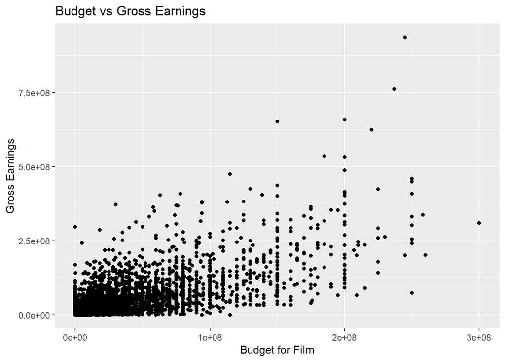

```r
ggplot(data = movies) + geom_point(mapping = aes(x = budget, y = gross)) + ggtitle("Budget vs Gross Earnings") + xlab("Budget for Film") + ylab("Gross Earnings")
```

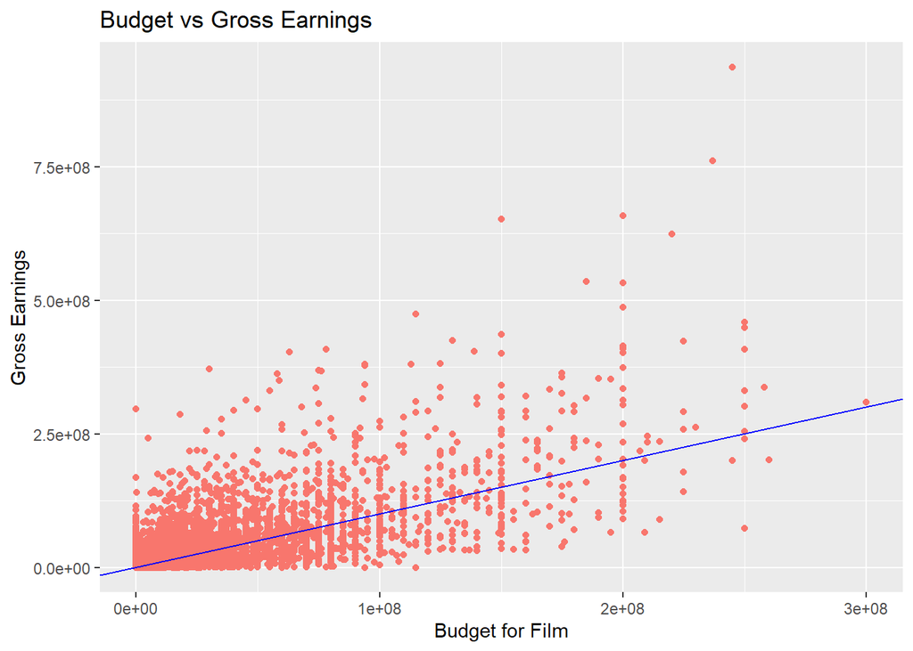

```r
ggplot(data = movies) + geom_point(mapping = aes(x = budget, y = gross, colour = "red")) + ggtitle("Budget vs Gross Earnings") + xlab("Budget for Film") + ylab("Gross Earnings") + geom_abline(color = 'blue') + guides(color = FALSE)
```

Even though it can be seen in the above plot, we can get a further understanding of this correlation by quantifying it.

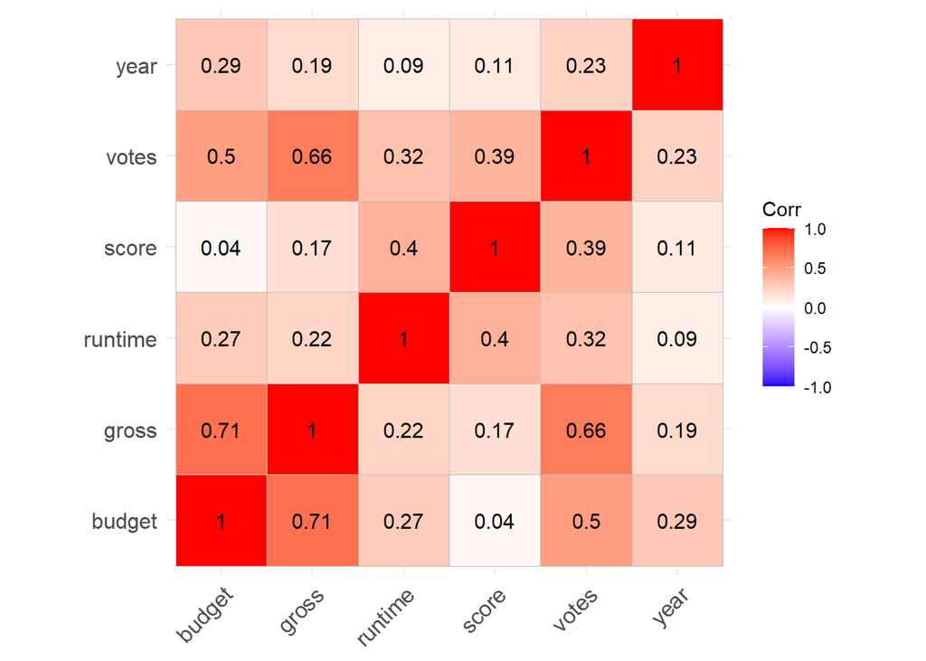

```r
corr_movies <- cor(movies[, sapply(movies, is.numeric)],
    use = "complete.obs", method = "pearson")
ggcorrplot(corr_movies, lab = TRUE)
```

As you can see in the correlation matrix, budget and gross earnings do indeed have a correlation.

## Conclusion

I appreciate you taking the time to look through this portfolio project of mine. This is just a small sample of what all I know how to do using the R language.